# ProjecteIII

[figure not shown]

## Desenvolupament Big Data PQTM 19

### Projecte III : Aprenentatge automatitzat i Bases de dades NoSQL

**Alumnos:** Nicolás D'Alessandro y Daniel Benitez García

## 00 - Enunciado

**Descripció:**

A partir de les dades que heu treballat en el projecte 2 cal que les deseu en una bases de dades distribuïda com és MongoDB. Amb aquestes dades farem servir TensorFlow i Keras (una API per a Deep Learning) per a calcular una regressió mitjançant xarxes neurals.

**Informació sobre com calcular una regressió amb TensorFlow:**

https://www.tensorflow.org/tutorials/keras/regression  
https://keras.io

**Objectius**

- Treballar amb TensorFlow 2.0
- Aplicar un algorisme d’aprenentatge automàtic
- Realitzar operacions CRUD amb MongoDB

## PARTE 1: Preparación del entorno de trabajo

### 00 - Definiciones

Instalamos la máquina Docker de cloudera

> docker pull cloudera/quickstart:latest

Arrancamos la máquina con los puertos para Spark UI, HUE y Jupyter abiertos, así como un directorio compartido

> sudo docker run --hostname=quickstart.cloudera --privileged=true -t -i -v /Users/danielbenitezbigdata/Documents/PythonWorkspace:/src --publish-all=true -p 8888 -p 4040:4040 -p 27017:27017 -p 8888:8889 -p 3333:3333 cloudera/quickstart: clouderatensorflowmongodb /usr/bin/docker-quickstart

Una vez arrancada la máquina docker, tenemos que saber que ID tiene ya que algunos comandos los lanzaremos desde el terminal remoto para ello ejecutar: docker ps Se tienen que instalar varios modulos para tener funcionando MongoDB, TensorFlow y TensorFlowOnSpark

Lo primero será actualizar a JAVA 8 ya que sino no podremos arrancar la versión de Spark necesaria para Python 3.7 que a su vez es necesaria para poder utilizar TensorFlow y TensorFlowOnSpark

> yum install java-1.8.0-openjdk

Se necesita tener wget para poder descargar tensorflow_docs y posteriormente descargar el repositorio de git e instalarlo

> docker exec -it sudo ./home/cloudera/anaconda/bin/conda install wget

> docker exec -it ./home/cloudera/anaconda/bin/wget --no-check-certificate --content-disposition https://github.com/tensorflow/docs.git

> docker exec -it sudo /home/cloudera/anaconda/bin/pip install /src/docs-master

En este momento ya se pueden instalar todos los módulos necesarios para TensorFlow, TensorFlowOnSpark y otros

> docker exec -it sudo /home/cloudera/anaconda/bin/pip install google

> docker exec -it sudo /home/cloudera/anaconda/bin/pip install --upgrade google-api-python-client

> docker exec -it sudo /home/cloudera/anaconda/bin/pip install protobuf

> docker exec -it sudo /home/cloudera/anaconda/bin/pip install tensorflow

> docker exec -it sudo /home/cloudera/anaconda/bin/pip install plotly

> Docker exec -it sudo /home/cloudera/anaconda/bin/pip install pyspark

> Docker exec -it sudo /home/cloudera/anaconda/bin/pip install tensorflowonspark

> Docker exec -it sudo /home/cloudera/anaconda/bin/pip install pyspark

Ahora se debe instalar MongoDB

Lo primero es crear la información para la instalación ejecutando:

> docker exec -it vi /etc/yum.repos.d/mongodb.repo

y escribiendo dentro del fichero:

### [mongodb-org-4.2]

> name=MongoDB Repository  
> baseurl=https://repo.mongodb.org/yum/redhat/$releasever/mongodb-org/4.2/x86_64/  
> gpgcheck=1  
> enabled=1  
> gpgkey=file:///tmp/key

Se debe crear el fichero con la key para la instalación de MongoDB

> docker exec -it vi /tmp/key

El contenido del fichero /tmp/key debe ser:

Con la instalción preparada se ejecutan los siguientes comandos para instalar los módulos necesarios:

> docker exec -it vi /etc/yum.repos.d/mongodb-org-4.2.repo

> docker exec -it sudo yum install mongodb-org

> docker exec -it sudo /home/cloudera/anaconda/bin/pip install pymongo

Llegados a este punto ya se puede ejecutar ESTE Jupyter Notebook

> docker exec sudo ./home/cloudera/anaconda/bin/jupyter notebook --ip=0.0.0.0 --port=333 --no-browser --allow-root

[figure not shown]

Adicionalmente se ha creado una imagen de docker en un repositorio público con la instalación explicada

[figure not shown]

```python
#importem les biblioteques que farem servir
import tensorflow_docs as tfdocs
import tensorflow_docs.plots
import tensorflow_docs.modeling

import pandas as pd

print("TensorFlow loaded!!!!!")
```

```
TensorFlow loaded!!!!!
```

```python
#from pyspark.context import SparkContext
#from pyspark.conf import SparkConf

#import tensorflowonspark as tfos
#from tensorflowonspark import TFCluster

#print("TensorFlowOnSpark LOADED!!!!")

#import argparse
#print("PySpark Loaded")
```

```python
#tf.__version__
```

```python
#tfos.__version__
```

instalamos pandas con Anaconda

> docker exec -it ./home/cloudera/anaconda/conda install pandas y matplotlib

> docker exec -it ./home/cloudera/anaconda/conda install matplotlib

```python
from __future__ import absolute_import, division, print_function, unicode_literals
# fem us de tensorflow 2
try:
  # %tensorflow_version per a indicar-ho en Colab.
  %tensorflow_version 2.x
except Exception:
  pass
import tensorflow as tf

from tensorflow import keras
from tensorflow.keras import layers

print(tf.__version__)
```

```
2.0.0
```

## PARTE 2: Operaciones CRUD en Mongo DB (Create, Read, Update, and Delete docs)

**Fuente**: Documentación oficial de MongoDB -> https://docs.mongodb.com/manual/crud/

### 00 - Establecemos la conexión con nuestra base de datos

```python
#importamos la librería para trabajar con Mongo desde python
import pymongo
import json
from pymongo import MongoClient
```

```python
#generamos el documento que importaremos a nuestra base de datos en mongo (datos del projecte II)
df_dl = pd.read_csv('df_ml.csv', index_col = 'Unnamed: 0')
document = df_dl.to_dict()
type(document)
```

```
dict
```

```python
def json_dict_print(json_data, limit=None):
    '''
    This function displays the content of the dictionary given limited by the optional parameter "limit":
        >>> Parameter 1: [DataFrame] Pandas DataFrame.
        ------------------------------------------------
        <<< Return: Content of the dictionary given limited by the optional parameter "limit"
    '''

    if isinstance(json_data, (str, int, float, bytes)):
        json_data = json.loads(json_data)
    nice = json.dumps(json_data, sort_keys=True, indent=3, separators=(',', ': '))

    print("\n".join(nice.split("\n")[0:limit]))

    if limit is not None:
        print("[...]")
```

```python
#utilizamos la función creada para observar en formato legible nuestro diccionario (ponemos limit 10)
json_dict_print(document, limit = 10)
```

```
{
   "PBI_ml": {
      "0": 2149930.079794,
      "1": 1287432.364323,
      "2": 1545503.444202,
      "3": 2169026.303259,
      "4": 1658637.446067,
      "5": 1572715.726761,
      "6": 1404395.917608,
      "7": 1190093.478674,
[...]
```

```python
#definimos los parámetros
url = 'mongodb://localhost:27017'
database_name = 'uoc'
collection_name = 'deep_learning'
```

```python
#establecemos la conexión con el cluster -> base de datos -> colección
cluster = pymongo.MongoClient(url)
db = cluster[database_name]
collection = db[collection_name]
```

### 01 - Create

Create Operations Create or insert operations add new documents to a collection. If the collection does not currently exist, insert operations will create the collection.

MongoDB provides the following methods to insert documents into a collection:

```
db.collection.insertOne() New in version 3.2
db.collection.insertMany() New in version 3.2
```

[figure not shown]

```python
#cargamos nuestro documento
data_json = json.loads(df_dl.to_json(orient='records'))
db.collection.insert_many(data_json)
```

```
<pymongo.results.InsertManyResult at 0x7f05ffbb3aa0>
```

### 02 - Read

Read operations retrieves documents from a collection; i.e. queries a collection for documents. MongoDB provides the following methods to read documents from a collection:

```
db.collection.find()
```

[figure not shown]

```python
#realizamos una consulta
query = { 'country': "Australia","year":2000}
result=db.collection.find(query)
for row in result:
    print(row)
```

```
{'_id': ObjectId('5dfa6450ac0abcf8d043d885'), 'country': 'Australia', 'year': 2000, 'contamination_ml': 5387.306, 'population_ml': 150343554.924, 'PBI_ml': 1104030.0, 'forest_ml': 48814.727, 'wage_ml': 53818.6726855619, 'life_expect_ml': 79.3}
```

### 03 - Update

Update operations modify existing documents in a collection. MongoDB provides the following methods to update documents of a collection:

```
db.collection.updateOne() New in version 3.2
db.collection.updateMany() New in version 3.2
db.collection.replaceOne() New in version 3.2
```

In MongoDB, update operations target a single collection. All write operations in MongoDB are atomic on the level of a single document.

[figure not shown]

```python
#db.collection.update()
```

### 04 - Delete

Delete operations remove documents from a collection. MongoDB provides the following methods to delete documents of a collection:

```
db.collection.deleteOne() New in version 3.2
db.collection.deleteMany() New in version 3.2
```

In MongoDB, delete operations target a single collection. All write operations in MongoDB are atomic on the level of a single document.

[figure not shown]

```python
#db.collection.delete_one()
```

## PARTE 3: Construcción de un Modelo de DL utilizando TensorFlow

### 00 - Importamos las bibliotecas necesarias

```python
import tensorflow_docs as tfdocs
import tensorflow_docs.plots
import tensorflow_docs.modeling

import pandas as pd
import seaborn as sns
import numpy as np
import category_encoders as ce
import matplotlib.pyplot as plt
from sklearn.preprocessing import StandardScaler
```

### 01 - Creamos todas las funciones necesarias para trabajar

**NOTA PARA EL PROFESOR:** Dada la cantidad de funciones, sería ideal la separación en clases y la creación de módulos que importaríamos en nuestro notebook. Por falta de tiempo y a modo de ejercicio, mostraremos las funciones en el mismo notebook.

#### EDA MODULE:

```python
def info(data):
    '''
    This function displays basic information about the given dataset.
        >>> Parameter 1: [DataFrame] Pandas DataFrame.
        ------------------------------------------------
        <<< Return: Dataset basic info.
    '''
    print('Column data types and description: \n')
    return data.info()



def describe(data):
    '''
    This function displays a basic description about the numerical features in the given dataset:
        >>> Parameter 1: [DataFrame] Pandas DataFrame.
        ------------------------------------------------
        <<< Return: Dataset basic description.
    '''
    print('Numerical values description:')
    return data.describe().round(2)



def nullvaluesf_count(data):
    '''
    This function displays the features that contains null values as well as the correspondig count:
        >>> Parameter 1: [DataFrame] Pandas DataFrame.
        ------------------------------------------------
        <<< Return: Features with null values and count.
    '''
    print('Features with null values:')
    null_values = {}
    for i in data.columns[data.isnull().any()]:
        null_values[i] = data.shape[0] - data.loc[:, i].count()

    return null_values



def categorical_info(data):
    '''
    This function displays name and count of unique values of the categorical features in the given dataset:
        >>> Parameter 1: [DataFrame] Pandas DataFrame.
        ------------------------------------------------
        <<< Return: Categorical features and count uniques
    '''
    print('Categorical features counts:')
    return data.select_dtypes(include= 'object').apply(lambda x: x.count())



def numerical_info(data):
    '''
    This function displays name and count of unique values of the numerical features in the given dataset:
        >>> Parameter 1: [DataFrame] Pandas DataFrame.
        ------------------------------------------------
        <<< Return: Numerical features and count uniques
    '''
    print('Numerical features counts:')
    return data.select_dtypes(include= ['int', 'float']).apply(lambda x: x.count())
```

#### FEATURE ENGINEERING MODULE:

```python
def target_encoding(data, column):
    '''
    This function performs a target encoding to the selected column for the given dataframe:
        >>> Parameter 1: [DataFrame] Pandas DataFrame.
        >>> Parameter 2: [str] Column we want to encode.
        ------------------------------------------------
        <<< Return: Head(5) of the transformed dataset.
    '''
    cbe = ce.cat_boost.CatBoostEncoder()
    cbe.fit(data, data[column])
    cbe.transform(data)

    return cbe.transform(data)


def data_normalize(data):
    '''
    This function normalize the data for the given dataframe using StandardScaler
        >>> Parameter 1: [DataFrame] Pandas DataFrame.
        ------------------------------------------------
        <<< Return: None
    '''
    data = pd.DataFrame(StandardScaler().fit_transform(data), columns=data.columns)

    return data
```

#### PLOTS MODULE

```python
def dataset_corr(data):
    '''
    This function displays the correlation matrix for the given DataFrame:
        >>> Parameter 1: [DataFrame] Pandas DataFrame.
        ------------------------------------------------
        <<< Return: Correlations values and matrix.
    '''
    sns.set(style="white")

    fig, ax = plt.subplots(figsize=(10,10))
    cmap = sns.diverging_palette(240, 10, as_cmap=True)

    sns.heatmap(data.corr(), annot=True, cmap=cmap, square=True, linewidths=.5, cbar_kws={"shrink": .5})

    return plt.show()


def create_pairplot(data):
    '''
    This function plot the pairplot grid for the given dataset:
        >>> Parameter 1: [DataFrame] Pandas DataFrame.
        ------------------------------------------------
        <<< Return: Plot.
    '''
    plt.style.use('Solarize_Light2')

    return sns.pairplot(data, diag_kind="kde", kind="reg")



def plot_history(metric):
    '''
    This function plot the epochs train history for the given metric:
        >>> Parameter 1: [str] Metric we want to plot.
        ------------------------------------------------
        <<< Return: Epoch history plot for the given metric.
    '''
    plt.style.use('ggplot')

    plt.figure(figsize=(10,6))
    plotter = tfdocs.plots.HistoryPlotter(smoothing_std=2)
    plt.suptitle('Epochs train history for ' + str(metric))
    plotter.plot({'Basic': history}, metric = metric)
    plt.ylim([0, 50])
    plt.ylabel('Metric [target_variable]')



def train_predictios_plot(test_values, predictions):
    '''
    This function plot a scatter plot between test_values and predictions:
        >>> Parameter 1: [DataFrame] Test_values.
        >>> Parameter 2: [DataFrame] Predictions.
        ------------------------------------------------
        <<< Return: Plot.
    '''

    prediccions_test = model.predict(test_values).flatten()
    df = pd.DataFrame(test_values)
    df['prediccions_test'] = prediccions_test

    plt.style.use('Solarize_Light2')

    plt.figure(figsize=(7,7))
    plt.scatter(df['life_expect_ml'], df['prediccions_test'])
    plt.xlabel('life_expect_ml', fontsize='x-large')
    plt.ylabel('prediccions_test', fontsize='x-large')
    plt.title('TEST VALUES VS. PREDICTIONS')

    return plt.show()


def target_corr(data, column):
    '''
    This function compute the correlations with the selected and the rest of variables for the given dataframe:
        >>> Parameter 1: [DataFrame] Pandas DataFrame.
        >>> Parameter 2: [str] Column target
        ------------------------------------------------
        <<< Return: Correlations dataframe.
    '''
    corr = pd.DataFrame(abs(data.corr()[column])).sort_values(by = column, ascending=True)
    df = corr[:-1]

    plt.style.use('ggplot')

    fig = plt.subplots(figsize= (8,4))
    plt.bar(df.index, df[column])
    plt.ylabel('pearson_correlation', fontsize= 'large')
    plt.xticks(df.index, rotation= 'vertical' )
    plt.show()

    return df.sort_values(by = column, ascending=False)
```

#### DEEP LEARNING MODEL MODULE

```python
def train_test_split(data, frac=0.75, random_state=0):
    '''
    This function split the given dataset into 'train' and 'test'.
        >>> Parameter 1: [DataFrame] Pandas DataFrame.
        ------------------------------------------------
        <<< Return: None
    '''

    global data_train
    data_train = data.sample(frac=frac, random_state=random_state)

    global data_test
    data_test = data.drop(data_train.index)

    print("Dataset properly separated. You have now the 'data_train' and 'data_test'available in your workbench"
          + '\n')

    print("The shape of the 'data_train' dataset is {} rows and {} columns".format(data_train.shape[0],
                                                                                   data_train.shape[1]))

    print("The shape of the 'data_test' dataset is {} rows and {} columns".format(data_test.shape[0],
                                                                           data_test.shape[1]))

def build_model(data, activation, layer, loss, metrics):
    '''
    This function build the model to perform a neural network regression with the given parameters.
        >>> Parameter 1: [dataframe] dataset
        >>> Parameter 2: [str] Activation function
        >>> Parameter 3: [int] Number of layers
        >>> Parameter 4: [str] Loss function
        >>> Parameter 5: [list] Metrisc
        ------------------------------------------------
        <<< Return: Model
    '''

    global model
    model = keras.Sequential([
        layers.Dense(layer, activation=activation, input_shape=[len(data.keys())]),
        layers.Dense(layer, activation=activation),
        layers.Dense(1)
    ])

    optimizer = tf.keras.optimizers.RMSprop(0.001)

    model.compile(loss=loss,
                optimizer=optimizer,
                metrics= metrics)
    print("Model created. You have now 'Model' available in your workbench\n\n")

    return model.summary()


def model_train(data_train_normalized, data_train_target, epochs, validation_split = 0.2, verbose=0):
    '''
    This function fit the model with the defined parameters into the given dataset.
        >>> Parameter 1: [dataframe] Train dataset
        >>> Parameter 2: [dataframe] Target dataset
        >>> Parameter 3: [int] Epochs
        >>> Parameter 4: [int] validation_split (by default = 0.2)
        >>> Parameter 5: [int] verbose (by default = 0)
        ------------------------------------------------
        <<< Return: Model
    '''



    try:
        global history
        history = model.fit(data_train_normalized, data_train_target,
                            epochs=epochs, validation_split = validation_split, verbose=verbose,
                            callbacks=[tfdocs.modeling.EpochDots()])

        print("Model fitted")

    except:

        print("An error ocurred")


def create_model_train_history():
    '''
    This function plot the epochs train history for the given metric:
        >>> Parameters: None
        ------------------------------------------------
        <<< Return: Dataframe with the historic results fof the model metrics by epoch.
    '''

    hist = pd.DataFrame(history.history)
    hist['epoch'] = history.epoch

    return hist.iloc[[0,-1],:]
```

### 02 - EDA: Análisis Exploratorio de datos

```python
#Recuperamos los datos de mongoDB
cursor=db.collection.find({}, {'_id': False})
df_dl=pd.DataFrame(list(cursor))
df_dl.head()
```

|  | country | year | contamination_ml | population_ml | PBI_ml | forest_ml | wage_ml | life_expect_ml |
| --- | --- | --- | --- | --- | --- | --- | --- | --- |
| 0 | Australia | 1990 | 5728.460 | 1.335825e+08 | 2.149930e+06 | 34859.0 | 44887.842550 | 77.0 |
| 1 | Australia | 1991 | 5747.308 | 1.353209e+08 | 1.287432e+06 | 35711.2 | 45081.484579 | 77.4 |
| 2 | Australia | 1992 | 5896.593 | 1.368764e+08 | 1.545503e+06 | 36563.4 | 46206.461459 | 77.5 |
| 3 | Australia | 1993 | 6120.709 | 1.381406e+08 | 2.169026e+06 | 37415.6 | 46882.868496 | 78.0 |
| 4 | Australia | 1994 | 6262.916 | 1.395673e+08 | 1.658637e+06 | 38267.8 | 47396.764410 | 78.0 |

```python
#visualizamos la forma de nuestro dataset
print("El dataset cargado tiene {} filas y {} columnas".format(df_dl.shape[0], df_dl.shape[1]))
```

```
El dataset cargado tiene 1005 filas y 8 columnas
```

```python
#visualizamos info básica del dataset
info(df_dl)
```

```
Column data types and description:

<class 'pandas.core.frame.DataFrame'>
RangeIndex: 1005 entries, 0 to 1004
Data columns (total 8 columns):
country             1005 non-null object
year                1005 non-null int64
contamination_ml    1005 non-null float64
population_ml       1005 non-null float64
PBI_ml              1005 non-null float64
forest_ml           1005 non-null float64
wage_ml             1005 non-null float64
life_expect_ml      1005 non-null float64
dtypes: float64(6), int64(1), object(1)
memory usage: 62.9+ KB
```

```python
#visualizamos los estadísticos básicos de nuestro dataset
describe(df_dl).transpose()
```

```
Numerical values description:
```

|  | count | mean | std | min | 25% | 50% | 75% | max |
| --- | --- | --- | --- | --- | --- | --- | --- | --- |
| year | 1005.0 | 2.003870e+03 | 7.990000e+00 | 1990.00 | 1997.00 | 2004.00 | 2.011000e+03 | 2.017000e+03 |
| contamination_ml | 1005.0 | 8.089100e+03 | 2.706766e+04 | 4.56 | 376.06 | 820.82 | 3.295480e+03 | 2.195713e+05 |
| population_ml | 1005.0 | 5.336384e+08 | 1.571443e+09 | 1973697.25 | 41069663.80 | 82581501.93 | 4.485086e+08 | 1.038599e+10 |
| PBI_ml | 1005.0 | 3.714825e+14 | 2.452194e+15 | 693.15 | 355822.34 | 1734637.60 | 1.352301e+07 | 3.474166e+16 |
| forest_ml | 1005.0 | 1.596047e+05 | 4.155241e+05 | 0.20 | 24329.59 | 50755.14 | 1.265655e+05 | 2.755525e+06 |
| wage_ml | 1005.0 | 7.674523e+05 | 2.812754e+06 | 4741.90 | 28362.61 | 42841.65 | 1.089003e+05 | 2.321981e+07 |
| life_expect_ml | 1005.0 | 7.763000e+01 | 3.720000e+00 | 64.30 | 75.60 | 78.20 | 8.050000e+01 | 8.420000e+01 |

```python
#comprobamos que no haya valores nulos
nullvaluesf_count(df_dl)
```

```
Features with null values:
```

```
{}
```

```python
#visualizamos info sobre las variables categoricas
categorical_info(df_dl)
```

```
Categorical features counts:
```

```
country    1005
dtype: int64
```

```python
#visualizamos info sobre las variables numéricas
numerical_info(df_dl)
```

```
Numerical features counts:
```

```
year                1005
contamination_ml    1005
population_ml       1005
PBI_ml              1005
forest_ml           1005
wage_ml             1005
life_expect_ml      1005
dtype: int64
```

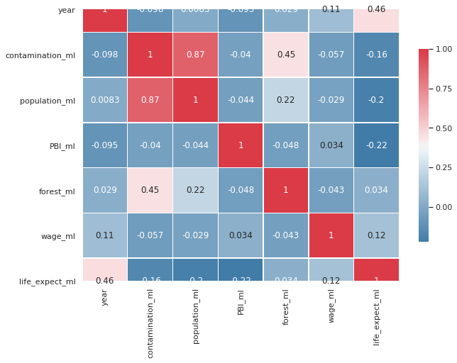

```python
#visualizamos la matriz de correlacion de
dataset_corr(df_dl)
```

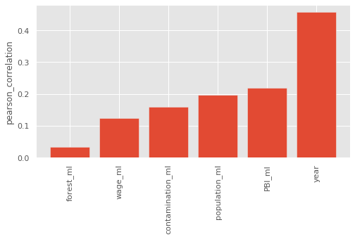

|  | life_expect_ml |
| --- | --- |
| year | 0.457765 |
| PBI_ml | 0.217871 |
| population_ml | 0.197451 |
| contamination_ml | 0.158431 |
| wage_ml | 0.122934 |
| forest_ml | 0.033855 |

```python
#observamos la correlación de cada feature con el target
target_corr(df_dl, 'life_expect_ml')
```

### 03 - Feature Engineering

```python
#aplicamos target encoding a las variables categoricas y visualizamos el resultado
df_dl = target_encoding(df_dl, 'life_expect_ml')
df_dl.head()
```

|  | country | year | contamination_ml | population_ml | PBI_ml | forest_ml | wage_ml | life_expect_ml |
| --- | --- | --- | --- | --- | --- | --- | --- | --- |
| 0 | 80.080277 | 1990 | 5728.460 | 1.335825e+08 | 2.149930e+06 | 34859.0 | 44887.842550 | 77.0 |
| 1 | 80.080277 | 1991 | 5747.308 | 1.353209e+08 | 1.287432e+06 | 35711.2 | 45081.484579 | 77.4 |
| 2 | 80.080277 | 1992 | 5896.593 | 1.368764e+08 | 1.545503e+06 | 36563.4 | 46206.461459 | 77.5 |
| 3 | 80.080277 | 1993 | 6120.709 | 1.381406e+08 | 2.169026e+06 | 37415.6 | 46882.868496 | 78.0 |
| 4 | 80.080277 | 1994 | 6262.916 | 1.395673e+08 | 1.658637e+06 | 38267.8 | 47396.764410 | 78.0 |

```python
#separamos nuestro dataset en "train" y "test"
train_test_split(df_dl)
```

```
Dataset properly separated. You have now the 'data_train' and 'data_test'available in your workbench

The shape of the 'data_train' dataset is 754 rows and 8 columns
The shape of the 'data_test' dataset is 251 rows and 8 columns
```

```python
#normalizamos los datos
data_train_normalized = data_normalize(data_train)
data_test_normalized = data_normalize(data_test)
data_train_normalized.head()
```

|  | country | year | contamination_ml | population_ml | PBI_ml | forest_ml | wage_ml | life_expect_ml |
| --- | --- | --- | --- | --- | --- | --- | --- | --- |
| 0 | -1.026044 | -0.241272 | -0.181140 | -0.143254 | -0.139948 | 0.107219 | -0.265576 | -0.833770 |
| 1 | 0.674105 | 1.278944 | -0.282458 | -0.315275 | -0.139948 | -0.203536 | -0.154844 | 1.209567 |
| 2 | 0.552749 | -1.001380 | -0.264205 | -0.286461 | -0.139948 | -0.368476 | -0.270188 | 0.080354 |
| 3 | 0.978662 | -0.621326 | -0.290210 | -0.340714 | -0.139948 | -0.372957 | 0.849954 | 0.456759 |
| 4 | 0.409223 | 0.645520 | -0.295098 | -0.339527 | -0.139948 | -0.372223 | -0.256503 | 0.806277 |

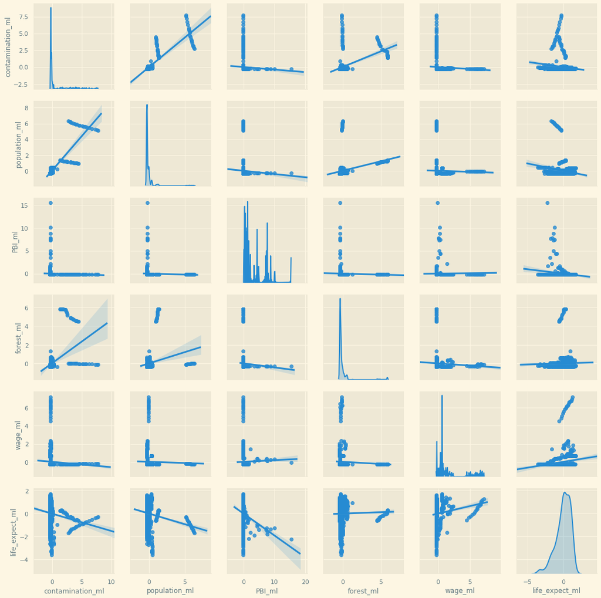

```python
#visualizamos nuevamente las correlaciones utilizando un pairplot
create_pairplot(data_train_normalized.drop(columns=['country', 'year']))
```

```python
#generamos las variables target a partir de nuestro dataset
target_data_train = data_train.pop('life_expect_ml')
target_data_test = data_test.pop('life_expect_ml')
```

### 04 - Construimos el Modelo

```python
#aplicamos la función creada para la construcción del modelo
build_model(df_dl, 'relu', 64, 'mse', ['mae', 'mse'])
```

```
Model created. You have now 'Model' available in your workbench


Model: "sequential_2"
_________________________________________________________________
Layer (type)                 Output Shape              Param #
=================================================================
dense_6 (Dense)              (None, 64)                576
_________________________________________________________________
dense_7 (Dense)              (None, 64)                4160
_________________________________________________________________
dense_8 (Dense)              (None, 1)                 65
=================================================================
Total params: 4,801
Trainable params: 4,801
Non-trainable params: 0
_________________________________________________________________
```

### 05 - Entrenamos el Modelo

```python
#utilizamos la función creada para entrenar el modelo
model_train(data_train_normalized, target_data_train, 600)
```

```
WARNING:tensorflow:Falling back from v2 loop because of error: Failed to find data adapter that can handle input: <class 'pandas.core.frame.DataFrame'>, <class 'NoneType'>

Epoch: 0, loss:5899.1933,  mae:76.7000,  mse:5899.1934,  val_loss:5702.7280,  val_mae:75.4051,  val_mse:5702.7280,
....................................................................................................
Epoch: 100, loss:0.4978,  mae:0.5770,  mse:0.4978,  val_loss:3.3299,  val_mae:0.7962,  val_mse:3.3299,
....................................................................................................
Epoch: 200, loss:0.2599,  mae:0.4413,  mse:0.2599,  val_loss:2.7772,  val_mae:0.4144,  val_mse:2.7772,
....................................................................................................
Epoch: 300, loss:0.2153,  mae:0.3599,  mse:0.2153,  val_loss:2.0671,  val_mae:0.4924,  val_mse:2.0671,
....................................................................................................
Epoch: 400, loss:0.2677,  mae:0.4305,  mse:0.2677,  val_loss:2.5625,  val_mae:0.5349,  val_mse:2.5625,
....................................................................................................
Epoch: 500, loss:0.1755,  mae:0.3349,  mse:0.1755,  val_loss:2.1440,  val_mae:0.3446,  val_mse:2.1440,
....................................................................................................Model fitted
```

### 06 - Evaluamos el Modelo

```python
#utilizamos la función creada y vemos como evolucionan las métricas entre el primer y el último epoch
create_model_train_history()
```

|  | loss | mae | mse | val_loss | val_mae | val_mse | epoch |
| --- | --- | --- | --- | --- | --- | --- | --- |
| 0 | 5899.193254 | 76.699989 | 5899.193359 | 5702.727969 | 75.405128 | 5702.728027 | 0 |
| 599 | 0.184625 | 0.318521 | 0.184625 | 1.480441 | 0.350311 | 1.480441 | 599 |

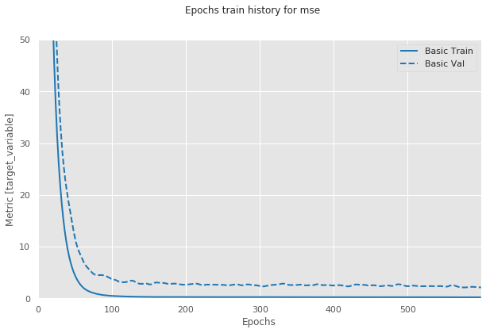

```python
#graficamos la history para el 'mse'
plot_history('mse')
```

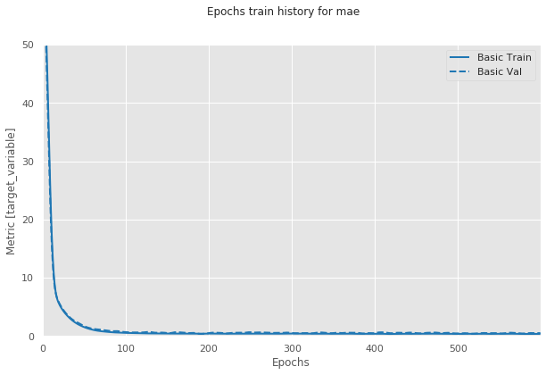

```python
#graficamos la history para el 'mae'
plot_history('mae')
```

```
WARNING:tensorflow:Falling back from v2 loop because of error: Failed to find data adapter that can handle input: <class 'pandas.core.frame.DataFrame'>, <class 'NoneType'>
```

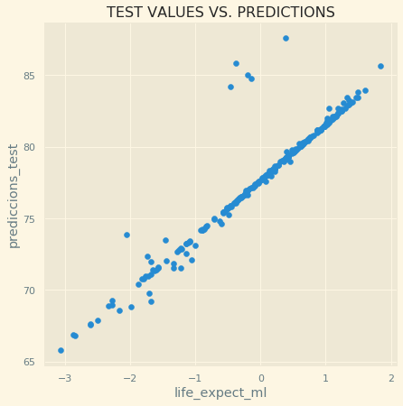

```python
#utilizamos la función creada para graficar un scatter de la predicción del modelo y los valores reales
train_predictios_plot(data_test_normalized, target_data_test)
```